# DV_RProject2: Vehicle Recalls

[figure not shown]

## 00. Create/Clone a github repository

Go to SourceTree software. Create new git repository in DataVisualization folder (on same level as DrCannata folder).

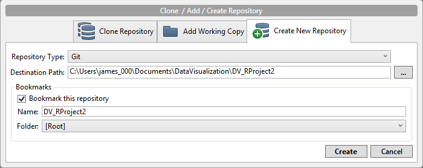

If did not create the repo, clone the repo in SourceTree software.

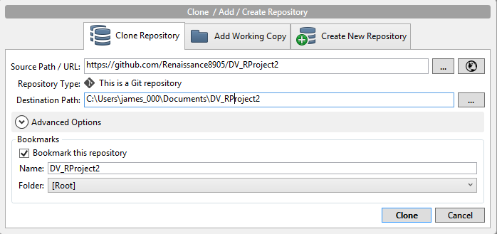

## 01. Create RStudio Project

Create an RStudio project in the project folder.

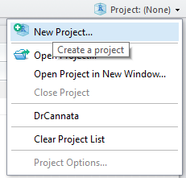

## 02. Setup RStudio

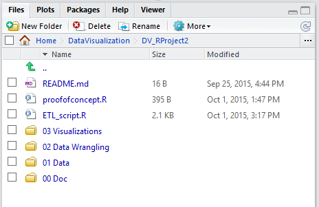

## 03. Download .CSV File

Download csv file documenting all vehicle recalls in Cannada.

[figure not shown]

## 04. ETL

```r
# ETL Script for Vehicle Recall Data for DV_RProject2
require(dplyr)
file_path <- ("~/DataVisualization/DV_RProject2/01 Data/vrdb_full_monthly.csv")

# read raw csv into dataframe df
df <- read.csv(file_path, stringsAsFactors = FALSE)

# scrub column names for periods, replace with underscore
names(df) <- gsub("\\.+", "_", names(df))

# check your data
str(df)
```

```
## 'data.frame':    77568 obs. of  14 variables:
##  $ RECALL_NUMBER_NUM         : chr  "1975001" "1975002" "1975002" "1975002" ...
##  $ YEAR                      : int  1975 1973 1973 1973 1973 1974 1974 1974 1974 1975 ...
##  $ MANUFACTURER_RECALL_NO_TXT: chr  "" "" "" "" ...
##  $ CATEGORY_ETXT             : chr  "Car" "Truck - Med. & H.D." "Truck - Med. & H.D." "Truck - Med. & H.D." ...
##  $ CATEGORY_FTXT             : chr  "Voiture" "Camion - usage moyen et usage intensif" "Camion - usage moyen et usage intensif" "Camion - usage moyen et usage intensif" ...
##  $ MAKE_NAME_NM              : chr  "VOLVO" "IHC" "IHC" "IHC" ...
##  $ MODEL_NAME_NM             : chr  "200 SERIES" "7070" "F4170" "F7070" ...
##  $ UNIT_AFFECTED_NBR         : chr  "2,700.00" "0.00" "0.00" "0.00" ...
##  $ SYSTEM_TYPE_ETXT          : chr  "Steering" "Not Entered" "Not Entered" "Not Entered" ...
##  $ SYSTEM_TYPE_FTXT          : chr  "Direction" "Non Saisie" "Non Saisie" "Non Saisie" ...
##  $ NOTIFICATION_TYPE_ETXT    : chr  "Safety Mfr" "Not Entered" "Not Entered" "Not Entered" ...
##  $ NOTIFICATION_TYPE_FTXT    : chr  "SÃ©curitÃ© - fabricant" "Non Saisie" "Non Saisie" "Non Saisie" ...
##  $ COMMENT_ETXT              : chr  "On certain Volvo 242, 244 and 245, the steering shaft nut could loosen" "HIGH LOAD STRESSES OCCUR IN CAB MOUNTING BRACKET FLANGES.  IF BREAKAGE SHOULD ODDUR, CAB ASSEMBLY COULD SHIFT AND AFFECT STEERI"| __truncated__ "HIGH LOAD STRESSES OCCUR IN CAB MOUNTING B…
##  $ COMMENT_FTXT              : chr  "Translation not available" "Translation not available" "Translation not available" "Translation not available" ...
```

```r
# defined 3 measures
measures <- c("RECALL_NUMBER_NUM", "YEAR", "UNIT_AFFECTED_NBR")

# scrub special characters
for(n in names(df)) {
  df[n] <- data.frame(lapply(df[n], gsub, pattern="[^ -~]",replacement= ""))
}

dimensions <- setdiff(names(df), measures)
if( length(measures) > 1 || ! is.na(dimensions)) {
  for(d in dimensions) {
    # Get rid of " and ' in dimensions.
    df[d] <- data.frame(lapply(df[d], gsub, pattern="[\"']",replacement= ""))
    # Change & to and in dimensions.
    df[d] <- data.frame(lapply(df[d], gsub, pattern="&",replacement= " and "))
    # Change : to ; in dimensions.
    df[d] <- data.frame(lapply(df[d], gsub, pattern=":",replacement= ";"))
  }
}

# no dates to format


# Get rid of all characters in measures except for numbers, the - sign, and periods
if( length(measures) > 1 || ! is.na(measures)) {
  for(m in measures) {
    df[m] <- data.frame(lapply(df[m], gsub, pattern="[^--.0-9]",replacement= ""))
  }
}

# uncomment to pare data down to 1/14th of original size (with evenly-spaced row selection)

#smalldf <- df %>% filter(row_number() %% 14 == 0)
#summary(smalldf)

#write.csv(smalldf, paste(gsub(".csv", "", file_path), ".reformatted.csv", sep=""), row.names=FALSE, na = "")

write.csv(df, paste(gsub(".csv", "", file_path), ".long.reformatted.csv", sep=""), row.names=FALSE, na = "")

tableName <- gsub(" +", "_", gsub("[^A-z, 0-9, ]", "", gsub(".csv", "", file_path)))
sql <- paste("CREATE TABLE", tableName, "(\n-- Change table_name to the table name you want.\n")
if( length(measures) > 1 || ! is.na(dimensions)) {
  for(d in dimensions) {
    sql <- paste(sql, paste(d, "varchar2(4000),\n"))
  }
}
if( length(measures) > 1 || ! is.na(measures)) {
  for(m in measures) {
    if(m != tail(measures, n=1)) sql <- paste(sql, paste(m, "number(38,4),\n"))
    else sql <- paste(sql, paste(m, "number(38,4)\n"))
  }
}
sql <- paste(sql, ");")
cat(sql)
```

```
## CREATE TABLE DataVisualizationDV_RProject201_Datavrdb_full_monthly (
## -- Change table_name to the table name you want.
##  MANUFACTURER_RECALL_NO_TXT varchar2(4000),
##  CATEGORY_ETXT varchar2(4000),
##  CATEGORY_FTXT varchar2(4000),
##  MAKE_NAME_NM varchar2(4000),
##  MODEL_NAME_NM varchar2(4000),
##  SYSTEM_TYPE_ETXT varchar2(4000),
##  SYSTEM_TYPE_FTXT varchar2(4000),
##  NOTIFICATION_TYPE_ETXT varchar2(4000),
##  NOTIFICATION_TYPE_FTXT varchar2(4000),
##  COMMENT_ETXT varchar2(4000),
##  COMMENT_FTXT varchar2(4000),
##  RECALL_NUMBER_NUM number(38,4),
##  YEAR number(38,4),
##  UNIT_AFFECTED_NBR number(38,4)
##  );
```

-Gives us:

```
CREATE TABLE DataVisualizationDV_RProject201_Datavrdb_full_monthly (
-- Change table_name to the table name you want.
 MANUFACTURER_RECALL_NO_TXT varchar2(4000),
 CATEGORY_ETXT varchar2(4000),
 CATEGORY_FTXT varchar2(4000),
 MAKE_NAME_NM varchar2(4000),
 MODEL_NAME_NM varchar2(4000),
 SYSTEM_TYPE_ETXT varchar2(4000),
 SYSTEM_TYPE_FTXT varchar2(4000),
 NOTIFICATION_TYPE_ETXT varchar2(4000),
 NOTIFICATION_TYPE_FTXT varchar2(4000),
 COMMENT_ETXT varchar2(4000),
 COMMENT_FTXT varchar2(4000),
 RECALL_NUMBER_NUM number(38,4),
 YEAR number(38,4),
 UNIT_AFFECTED_NBR number(38,4)
 );
```

## 05. Peculiarities

-Encountered JSON parsing error when trying to fetch database

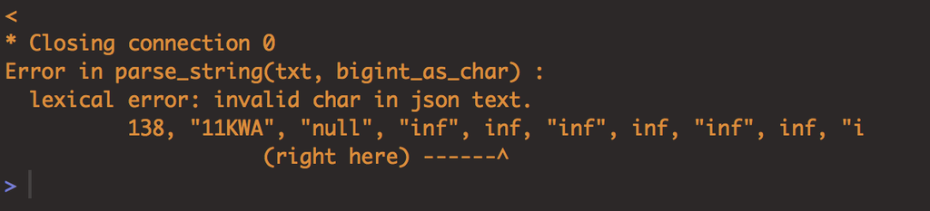

-After some sleuthing, pinpointed problem rows in database:

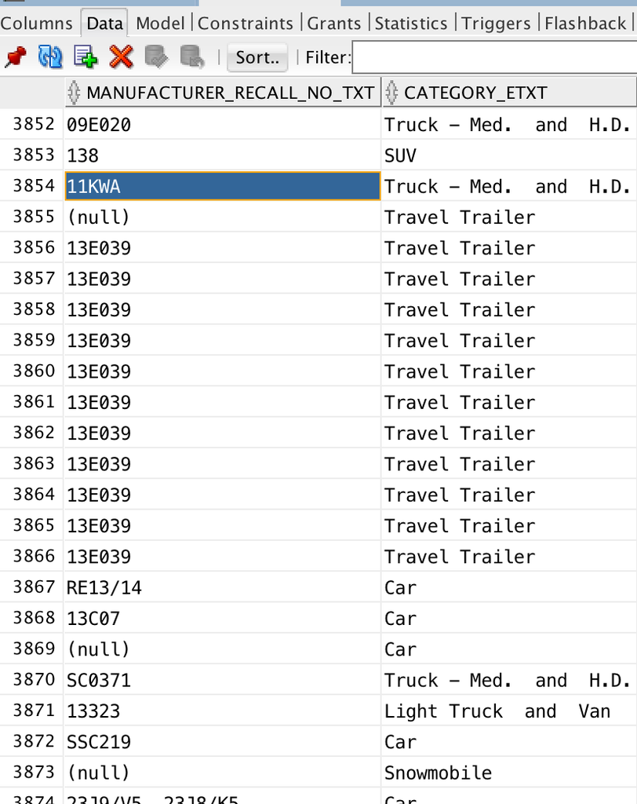

-The values looked strange, but nothing about them explained why JSON had read them as infinity. The csv files held some answers though…

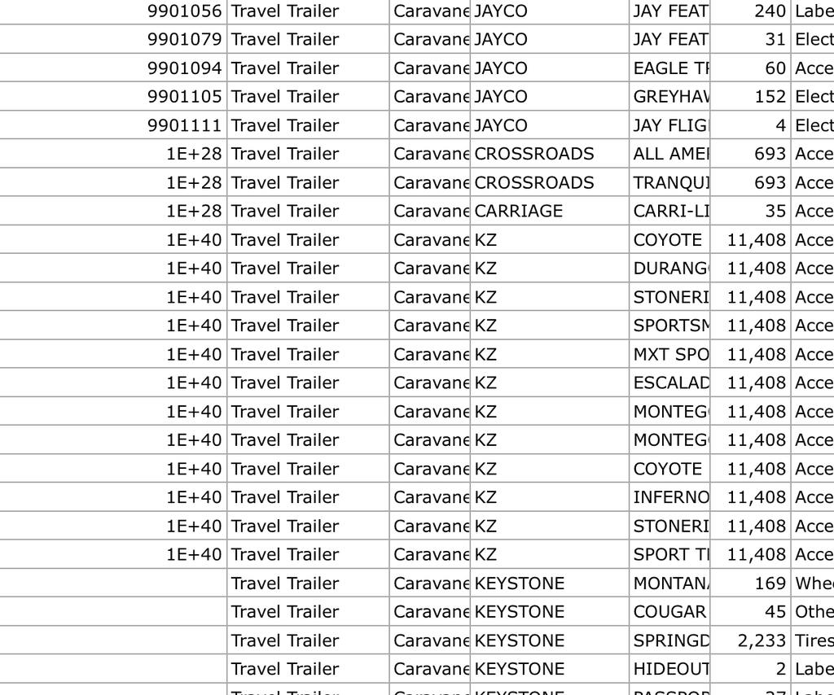

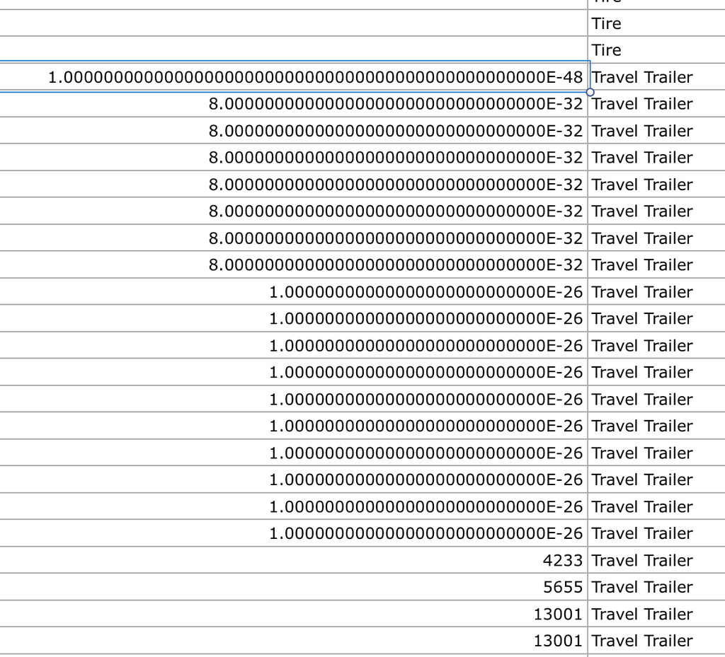

-A-ha! Some values in the original csv contained some codes in a number-‘E’-number format, and upon reformatting they had been parsed as scientific notation.

-Very few rows even contained values in the offending column, so the simplest solution seemed to be to drop the column entirely from our data. There didn’t seem to be any pattern to Manufacturer’s recall codes anyway.

-Oracle was reacting badly to the offending data, so we eventually opted to drop the table entirely and rebuild it with a modified SQL statement.

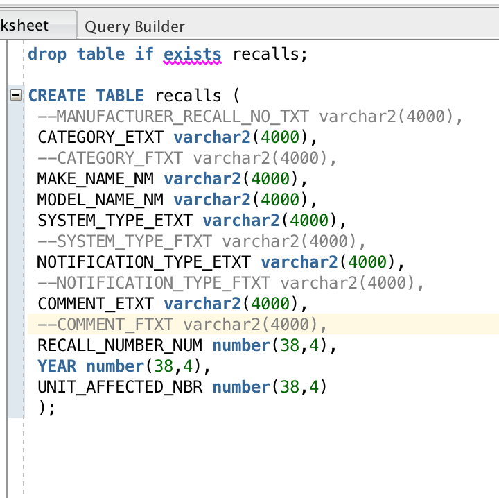

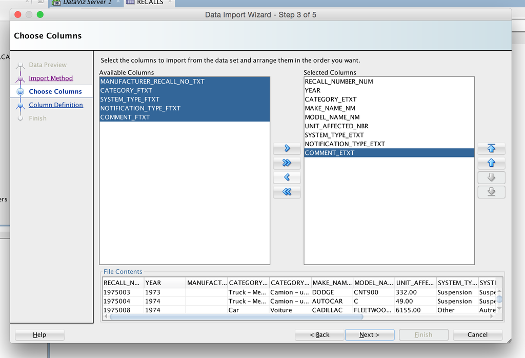

-While we were at it we pulled out four columns that were french translations of other columns. None of us speak French.

## 06. Summary and Subset

Creating dataframe from Oracle’s database with SQL query:

```r
require("jsonlite")
require("RCurl")
```

```r
df <- data.frame(fromJSON(getURL(URLencode('129.152.144.84:5001/rest/native/?query="select * from recalls"'),httpheader=c(DB='jdbc:oracle:thin:@129.152.144.84:1521/PDBF15DV.usuniversi01134.oraclecloud.internal', USER='cs329e_qan74', PASS='orcl_qan74', MODE='native_mode', MODEL='model', returnDimensions = 'False', returnFor = 'JSON'), verbose = TRUE), ))
```

### Summary of Dataframe

```r
summary(df)
```

```
##                  CATEGORY_ETXT         MAKE_NAME_NM
##  Truck - Med.  and  H.D.:1142   FORD         : 268
##  Car                    : 989   INTERNATIONAL: 230
##  Motorhome              : 600   CHEVROLET    : 193
##  Travel Trailer         : 469   MACK         : 161
##  Bus                    : 440   FREIGHTLINER : 153
##  Light Truck  and  Van  : 385   THOMAS BUILT : 149
##  (Other)                :1515   (Other)      :4386
##                    MODEL_NAME_NM     SYSTEM_TYPE_ETXT
##  CONVENTIONAL             :  23   Other      :1062
##  SAF-T-LINER C2 SCHOOL BUS:  23   Brakes     : 621
##  RAM                      :  22   Electrical : 539
##  4900                     :  21   Not Entered: 396
##  C SERIES                 :  20   Steering   : 382
##  H3-45 COACH              :  19   Fuel Supply: 365
##  (Other)                  :5412   (Other)    :2175
##     NOTIFICATION_TYPE_ETXT
##  Safety Mfr    :3810
##  Recalls Audit : 429
##  Safety TC     : 375
##  Not Entered   : 368
##  Compliance Mfr: 321
##  Compliance TC : 173
##  (Other)       :  64
##                                                                                                                                                                                                                                                                                                          …
##  On certain motorhomes, conventional travel trailers and fifth wheel travel trailers equipped with a Dometic Corporation refrigerator, a fatigue crack can develop in the boiler tube.  This could allow the release of pressurized coolant solution into an area where an ignition source is present, wh…
##  Certain refrigerators used in Recreational Vehicles (RVs) contain either a sensing algorithm or a thermal switch to interrupt power when it detects high temperatures that could lead to a fire.  An insufficient response time can result in the power not being shut-off in sufficient time to prevent…
##  On certain recreational vehicles equipped with a Samsung microwave oven, an electrical short can occur in the microwave ovens membrane panel keypad causing the oven to activate without pressing any keypads.  This could result in excessive heat, smoke or possibly a fire.  Correction;  Samsung wil…
##  On certain vehicles, the internal rubber check valve inside the Bendix SR-7 spring brake modulating valve can become deformed over time.  The effect of this defect is intermittent and presents a potential delay or failure in applying the parking brakes; potentially resulting in a vehicle roll aw…
##  Certain travel trailers and motorhomes equipped with a Norcold gas/electric refrigerator model  442, 443, 452, EV452, 453, 462, EV462, 463, EV463, 482, EV482, 483, EV483, 874 and 875 manufactured between January 1987 and May 1995 may have a propane leak from the gas valve.  As the rubber seal wi…
##  Certain off-road motorcycles, ATVs and competition motorcycles do not have the required bilingual warning label indicating that the vehicle is a restricted use motorcycle or an all-terrain vehicle and is not intended for use on public highways.  These vehicle were equipped with a label in one of…
##  (Other)                                                                                                                                                                                                                                                                                                 …
##  RECALL_NUMBER_NUM      YEAR       UNIT_AFFECTED_NBR
##  Min.   : 198003   Min.   :-9999   Min.   :     0
##  1st Qu.:1998159   1st Qu.: 1995   1st Qu.:   120
##  Median :2006346   Median : 2003   Median :   949
##  Mean   :1995555   Mean   : 1987   Mean   : 24542
##  3rd Qu.:2010328   3rd Qu.: 2008   3rd Qu.:  8328
##  Max.   :2015385   Max.   : 2016   Max.   :834368
##
```

### Subset of Dataframe

A subset of recalls dataframe where number of units affected for each category is greater than 400,000:

```r
head(subset(df, as.numeric(as.character(UNIT_AFFECTED_NBR)) > 400000))
```

```
##      CATEGORY_ETXT MAKE_NAME_NM MODEL_NAME_NM       SYSTEM_TYPE_ETXT
## 294            Car      PONTIAC    GRAND PRIX             Suspension
## 295            Car      PONTIAC  GRAND LEMANS             Suspension
## 296            Car   OLDSMOBILE CUTLASS SALON             Suspension
## 918            Car      MERCURY        COUGAR Lights And Instruments
## 919            Car      MERCURY        COUGAR Lights And Instruments
## 1049           Car        ACURA       INTEGRA   Seats And Restraints
##      NOTIFICATION_TYPE_ETXT
## 294               Safety TC
## 295               Safety TC
## 296               Safety TC
## 918               Safety TC
## 919               Safety TC
## 1049              Safety TC
##                                                                                                                                                                                                                                                                                                          …
## 294                                                                                                                                                                                                           On certain vehicles, the lower rear control arm to frame bolts may fracture causing lower c…
## 295                                                                                                                                                                                                           On certain vehicles, the lower rear control arm to frame bolts may fracture causing lower c…
## 296                                                                                                                                                                                                           On certain vehicles, the lower rear control arm to frame bolts may fracture causing lower c…
## 918  NOTE; ALSO INCLUDES SOME MEDIUM AND HEAVY TRUCKS.  THESE VEHICLES MAY NOT COMPLY WITH C.M.V.S.S. 108 - LIGHTING.   DAYTIME RUNNING LIGHT MODULE MAY MALFUNCTION WHICH CAN RESULT IN DAYTIME  RUNNING LIGHTS THAT DIM, FLICKER OR GO OFF OR IN SOME INSTANCES MAY  REMAIN ON AFTER THE IGNITION IS TU…
## 919  NOTE; ALSO INCLUDES SOME MEDIUM AND HEAVY TRUCKS.  THESE VEHICLES MAY NOT COMPLY WITH C.M.V.S.S. 108 - LIGHTING.   DAYTIME RUNNING LIGHT MODULE MAY MALFUNCTION WHICH CAN RESULT IN DAYTIME  RUNNING LIGHTS THAT DIM, FLICKER OR GO OFF OR IN SOME INSTANCES MAY  REMAIN ON AFTER THE IGNITION IS TU…
## 1049      On certain vehicles, the platic front seatbelt release buttons may break allowing plastic pieces to fall into the buckle assembly.  If this should happen, a no latch, false latch or failure to unlatch condition could occur creating the risk of personal injury in the event of a crash or …
##      RECALL_NUMBER_NUM YEAR UNIT_AFFECTED_NBR
## 294            1981027 1979            486090
## 295            1981027 1980            486090
## 296            1981027 1981            486090
## 918            1992077 1990            464543
## 919            1992077 1991            464543
## 1049           1995086 1989            423467
```

## 07. Visualizations

### Plot #1. Honda/Acura Recalls

Description:

- My workflow only looks at 4 columns: Maker (filtered as Honda or Acura), System Failure Type, Number of Units Affected and Year.
- The new dataframe is grouped by Year, and further filtered by System Failure Type to ignore entries that are either “Accessories” or “Label” (as I consider “Accessories” and “Label” to be trivial recall reasons).

```r
require(tidyr)
```

```r
require(dplyr)
require(ggplot2)
quandf <- df %>% select(MAKE_NAME_NM, SYSTEM_TYPE_ETXT, UNIT_AFFECTED_NBR, YEAR) %>% group_by(YEAR) %>% filter(MAKE_NAME_NM %in% c("HONDA", "ACURA"), SYSTEM_TYPE_ETXT != "Accessories", SYSTEM_TYPE_ETXT != "Label")
```

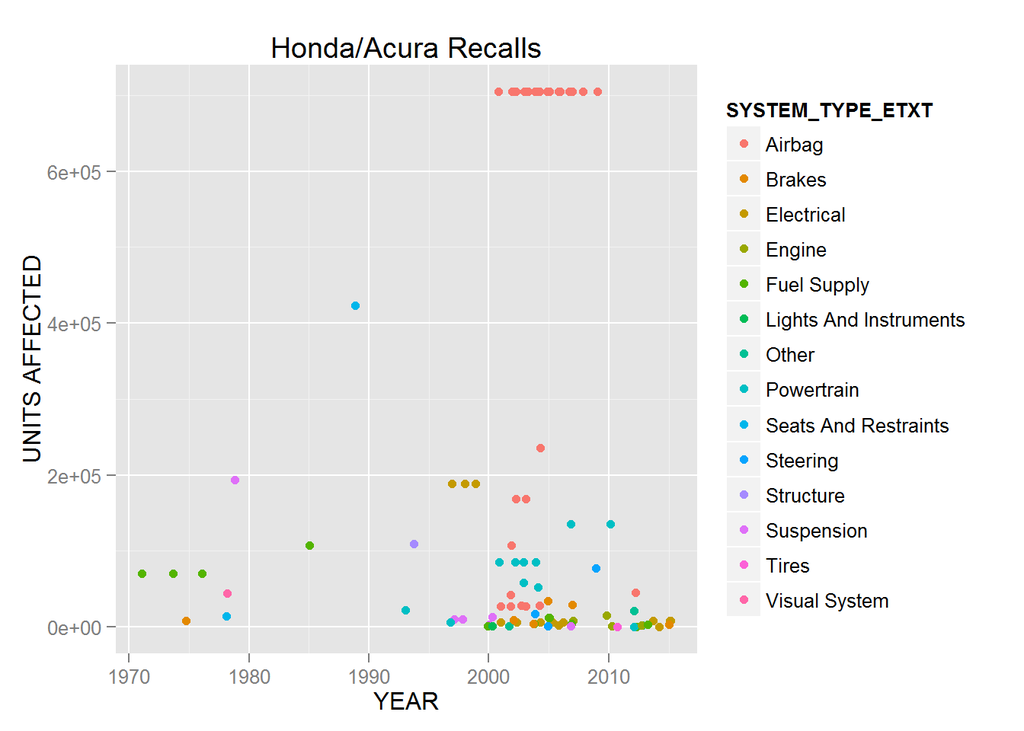

```r
ggplot() +
  coord_cartesian() +
  scale_x_continuous() +
  scale_y_continuous() +
  labs(title='Honda/Acura Recalls') +
  labs(x="YEAR", y="UNITS AFFECTED") +
  layer(data=quandf,
        mapping=aes(x= as.numeric(as.character(YEAR)), y=as.numeric(as.character(UNIT_AFFECTED_NBR)), color=SYSTEM_TYPE_ETXT),
        stat="identity",
        stat_params=list(),
        geom="point",
        geom_params=list(),
        position=position_jitter(width=0.3, height=0)
)
```

Comment:

- The generated plot shows the number of Honda/Acura units recalled by each type of system failure over the years.
- The interesting point here is the abnormally high number of units recalled due to Airbag problem/failure in the period 2000-2010. The number is staggering compared to other scattered recalls (more than 700,000 units each year compared to the norm of below 200,000 units for other types of recall), occupying a conspicuous horizontal line at the top of the graph.
- In fact, I wonder whether this might correspond to the major Takata airbag recall by Honda. The airbags, made by major parts supplier Takata, were mostly installed in cars from model year 2002 through 2008.

### Plot #2: Recalls Affecting Child Safety

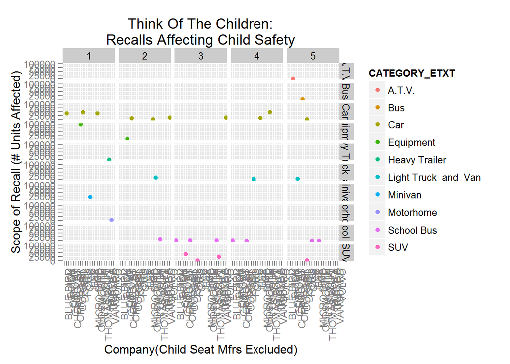

```r
df %>% filter(grepl("[Cc]hild|CHILD", COMMENT_ETXT)) %>% filter(CATEGORY_ETXT != "Child Car Seat" & CATEGORY_ETXT != "Booster Seat") %>% filter(YEAR > 1900) %>% mutate(decade = ntile(YEAR,5)) %>% group_by(MAKE_NAME_NM, YEAR, UNIT_AFFECTED_NBR, CATEGORY_ETXT, decade) %>%  ggplot(aes(x=MAKE_NAME_NM, y=UNIT_AFFECTED_NBR, color=CATEGORY_ETXT)) + geom_point() + theme(axis.text.x = element_text(angle = 90, hjust = 1)) + labs(title="Think Of The Children:\nRecalls Affecting Child Safety") + labs(x="Company(Child Seat Mfrs Excluded)", y="Scope of Recall (# Units Affected)") + facet_grid(~CATEGORY_ETXT~decade)
```

- In terms of total units recalled over the last 45 years, Ford is the clear frontrunner. However, Suzuki holds the distinction of having one of the two most widespread recalls, and having it in the 21st century– at a point when most manufacturer’s child-safety recalls were on the decline.